# Final Project Data

Author

Kristina Hildebrandt

# Introduction

For my project I found aviation accident and event records from the National Transportation and Safety Board. I wanted to learn about the prevalence/occurrence of accidents in the last 50ish years. I also was interested in the listed of causes for most accidents. My audience was the average adult living in the United States with no prior (or barely prior) knowledge or experience of the aviation industry. It seems like aircrafts are just falling out of the sky over the last few years. This year alone, I think about the plane crash in the East with the ice skating team, the helicopter sightseeing crash, the flipping of the Delta plane in Canada, and the small airplane that crashed in our own Brooklyn Park, Minnesota. I think many people feel like there is a rise in aviation tragedies but don’t know why. Thus, I think it’s pertinent to start analyzing data we have about aviation safety.

My aim with my communication was to produce a website-like blog. I wanted the data to be informative but still interesting for the public. I wanted it to be like an independent yet not super serious news post that anyone could access online. I thought a blog/website could be a practical and engaging way to try to tell the story of my data (Yau, 2011). It also appears that much of aviation data and national safety know how to attractively show their data, nor is necessarily the best at keeping it well maintained in the public eye. Maybe this project can make aviation data more accessible and interesting for the public (Andrews, 2022)

# Packages Used

```r
library(tidyverse)
library(dplyr)
library(odbc)
library(visdat)
library(data.table)
library(purrr)
library(forcats)
library(scales)
library(jsonlite)
library(usmap)
library(ggh4x)
```

# Importing the Data from NTSB

I used SQL queries to open the microsoft access files.

```r
conn <- dbConnect(odbc::odbc(),
                  Driver = "Microsoft Access Driver (*.mdb, *.accdb)",
                  DBQ = "C:/Users/kamer/OneDrive/Documents/Sp25/336Final/avall.mdb")

tables <- dbListTables(conn)
print(tables)
```

```
 [1] "MSysAccessObjects"          "MSysACEs"
 [3] "MSysIMEXColumns"            "MSysIMEXSpecs"
 [5] "MSysModules2"               "MSysNavPaneGroupCategories"
 [7] "MSysNavPaneGroups"          "MSysNavPaneGroupToObjects"
 [9] "MSysNavPaneObjectIDs"       "MSysObjects"
[11] "MSysQueries"                "MSysRelationships"
[13] "aircraft"                   "Country"
[15] "ct_iaids"                   "ct_seqevt"
[17] "dt_aircraft"                "dt_events"
[19] "dt_Flight_Crew"             "eADMSPUB_DataDictionary"
[21] "engines"                    "events"
[23] "Events_Sequence"            "Findings"
[25] "Flight_Crew"                "flight_time"
[27] "injury"                     "narratives"
[29] "NTSB_Admin"                 "Occurrences"
[31] "seq_of_events"              "states"
```

```r
event <- dbGetQuery(conn, "SELECT * FROM events")

craft <- dbGetQuery(conn, "SELECT * FROM aircraft")

injure <- dbGetQuery(conn, "SELECT * FROM injury")

reason <- dbGetQuery(conn, "SELECT * FROM Findings")

dbDisconnect(conn)
```

```r
conn <- dbConnect(odbc::odbc(),
                  Driver = "Microsoft Access Driver (*.mdb, *.accdb)",
                  DBQ = "C:/Users/kamer/OneDrive/Documents/Sp25/336Final/Pre2008.mdb")

tables08 <- dbListTables(conn)
print(tables08)
```

```
 [1] "MSysAccessObjects"            "MSysACEs"
 [3] "MSysIMEXColumns"              "MSysIMEXSpecs"
 [5] "MSysModules2"                 "MSysNavPaneGroupCategories"
 [7] "MSysNavPaneGroups"            "MSysNavPaneGroupToObjects"
 [9] "MSysNavPaneObjectIDs"         "MSysObjects"
[11] "MSysQueries"                  "MSysRelationships"
[13] "aircraft"                     "Country"
[15] "ct_iaids"                     "ct_seqevt"
[17] "dt_aircraft"                  "dt_events"
[19] "dt_Flight_Crew"               "eADMSPUB_DataDictionary"
[21] "engines"                      "events"
[23] "Events_Sequence"              "Findings"
[25] "Flight_Crew"                  "flight_time"
[27] "injury"                       "narratives"
[29] "NTSB_Admin"                   "Occurrences"
[31] "seq_of_events"                "states"
[33] "Basic Query"                  "qryInjurySummary Totals-XTAB"
[35] "qryInjurySummaryAC"           "qryinjurySummary-OGRND"
[37] "qryInjurySummary-XTAB"        "qryTriNat"
[39] "SearchEvent"                  "SingleAircraft_make"
[41] "SingleEvent_make"
```

```r
event08 <- dbGetQuery(conn, "SELECT * FROM events")

injure08 <- dbGetQuery(conn, "SELECT * FROM injury")

craft08 <- dbGetQuery(conn, "SELECT * FROM aircraft")

dbDisconnect(conn)
```

# Tidying the Data How I Will Need It

This section unfortunately did not make it into my final project due to wrong cases of years being in different tables (I checked and this happened right after importing the tables before I edit anything, so it probably occurred at the sources/time of publishing?). However, I am still including where I left everything because this process took up a good chunk of my time.

I decided that I need to create my own function when pivoting the injury table into becoming wider so each case would be a single event (rather than individual planes as the cases). I tried looking for a built in function in which NA + NA = NA, 0 + NA = 0, x>=1 where x + NA = x. I could not find any exactly how I needed it so below is my custom function.

```r
# ignore_add_NA <- function(x) {
#   if (all(is.na(x))) {
#     return(NA_real_)
#   }
#   if (all(x %in% c(NA, 0))) {
#     return(NA_real_)
#   }
#   return(sum(x, na.rm = TRUE))
# }
```

Here I selected the variables I thought could come in handy. I also double-checked that the date variable was of date type. I then needed to pivot wider a few variables. This worked out better to do in two functions. For example, different events had different number of aircrafts involved, so I had to move that to new columns. I also had to move the type of injury up into new columns with the count of each type in the cells. I renamed a few of these new variables since they were shortened while inside the cells (like FATL). I used my custom function when summarizing by each specific event.

Tidy Injure:

```r
# injure <- injure|>
#   select(c(1:7)) |>
#   mutate(date = ymd_hms(lchg_date)) |>
#   select( - c(lchg_date, lchg_userid)) |>
#   rename(inj_count = inj_person_count) |>
#
#   pivot_wider(names_from = c("injury_level"),
#               values_from="inj_count") |>
#   pivot_wider(names_from = "Aircraft_Key",
#               values_from = "Aircraft_Key",
#               names_glue = "{Aircraft_Key}_{.value}") |>
#
#   mutate(present = 1) |>
#   mutate(present = as.numeric(present)) |>
#   pivot_wider(names_from = inj_person_category,
#     values_from = present,
#     values_fill = list(present = 0)) |>
#
#   rename(fatal = FATL) |>
#   rename(serious = SERS) |>
#   rename(minor = MINR) |>
#   rename(unharmed = NONE) |>
#   rename(total_inj = TOTL) |>
#   rename(event = ev_id) |>
#
#   #Needed to merge injure and injure08
#   select(-c("LapC", "Flig", "Cabi")) |>
#
#   group_by(event, date) |>
#   summarize(across(where(is.numeric), ignore_add_NA))
```

This is primarily where the injure table went wrong (thus I kept the work but commented out). Injure08 is the injury data from 1982-2008, and yet only cases from about 2020-2023 were included (I am still stumped, I will still think about it sometimes hoping it is not some stupid mistake of mine).

Tidy injure08:

```r
#
# injure08 <- injure08|>
#   select(c(1:7)) |>
#   mutate(date = ymd_hms(lchg_date)) |>
#   select( - c(lchg_date, lchg_userid)) |>
#   rename(inj_count = inj_person_count) |>
#
#   pivot_wider(names_from = c("injury_level"),
#               values_from="inj_count") |>
#   pivot_wider(names_from = "Aircraft_Key",
#               values_from = "Aircraft_Key",
#               names_glue = "{Aircraft_Key}_{.value}") |>
#
#   mutate(present = 1) |>
#   pivot_wider(names_from = inj_person_category,
#     values_from = present,
#     values_fill = list(present = 0)) |>
#
#   rename(fatal = FATL) |>
#   rename(serious = SERS) |>
#   rename(minor = MINR) |>
#   rename(unharmed = NONE) |>
#   rename(total_inj = TOTL) |>
#   rename(event = ev_id) |>
#
#   #Needed for injure and injure08 merge
#   select(-c("4_Aircraft_Key")) |>
#
#   group_by(event, date) |>
#   summarize(across(where(is.numeric), ignore_add_NA))
```

Below is the start of the tidying needed for the table called aircraft which held more specifics of the plane and gear on board. There were so many variables so I had to focus on certain ones. Since this was still earlier in the phase, I kept a lot more variables than I will use since I questioned if I would need the others later in my project. I again double checked that the date variable (this time the inspection date, not accident date), was of a date type. Then for later down the road, I created a binary variable for aircrafts that were or were not airplanes. I thought this project would be more relatable to my audience if it was just focused on airplanes, since aircrafts are familiar to most people.

Tidy craft (ntsb_no unique, event_id shared among planes ivolved):

```r
craft <- craft|>
  select(c(1:18, 20:33, 60, 62:66, 69:72, 82:86, 88, 89)) |>
  select(-c(elt_mounted_aircraft, phase_flt_spec, dprt_timezn,
            dprt_pt_same_ev, elt_type)) |>
  mutate(date_insp = ymd(date_last_insp)) |>
  select(- c(date_last_insp)) |>
  relocate(ntsb_no, .before=1) |>
  mutate(plane = if_else(acft_category=="AIR", TRUE, FALSE)) |>
  relocate(ntsb_no, .before=3)
```

Below is the pre 2008 data table of aircraft.

Tidy craft08:

```r
craft08 <- craft08|>
  select(c(1:18, 20:33, 60, 62:66, 69:72, 82:86, 88, 89)) |>
  select(-c(elt_mounted_aircraft, phase_flt_spec, dprt_timezn,
            dprt_pt_same_ev, elt_type)) |>
  mutate(date_insp = ymd(date_last_insp)) |>
  select(- c(date_last_insp)) |>
  relocate(ntsb_no, .before=1) |>
  mutate(plane = if_else(acft_category=="AIR", TRUE, FALSE)) |>
  relocate(ntsb_no, .before=3)
```

This “reason” table held a few columns about potential causes and reasons for each crash. This table had a similar problem like the injure section in which the pre2008 section only had a handful of cases that were not in the correct year range. However, I planned to use these variables as proportions rather than hard counts like I had planned for “injure”. Thus, I still used this reason table, but just from the post2008 section.

Tidy reason:

```r
reason <- reason|>
  select(c(1:5, 12))|>
  mutate(date = ymd_hms(lchg_date))|>
  select(-c(lchg_date, Aircraft_Key, finding_no)) |>
  rename(description = finding_description)

reason_as_list <- reason |>
  group_by(ev_id) |>
  slice_head(n=3) |>
  mutate(row = row_number()) |>
  ungroup() |>
  pivot_wider(id_cols = ev_id,
              names_from = row,
              values_from = c(description, finding_code),
              names_glue = "{.value}_{row}")
```

The event table turned out to be my main source of data. This table had the most amount of cases by the actual event, and had a wide spread of years. I selected specific columns again (keeping any useful column in case information was needed later). I then decided to filter for “ACC” which stood for accident instead of the other option of incident. My main focus for this analysis was serious crashes and accidents involving airplanes. Especially taking from my personal background from when I was flying planes at a flight school, incidents are quite common and can be quite little things that are required to be reported.

Tidy event:

```r
event <- event|>
  select(c(1:7, 8:11, 15:18, 23, 34:38, 50, 54, 60)) |>
  select(-c(ev_tmzn)) |>
  mutate(date = ymd(ev_date)) |>
  select(-c(ev_date)) |>
   filter(ev_type=="ACC") |>
  select(-c(ev_type)) |>
  rename(day = ev_dow)
```

Here is the pre 2008 portion for events.

Tidy event08:

```r
event08 <- event08|>
  select(c(1:7, 8:11, 15:18, 23, 34:38, 50, 54, 60)) |>
  select(-c(ev_tmzn)) |>
  mutate(date = ymd(ev_date)) |>
  select(-c(ev_date)) |>
  filter(ev_type=="ACC") |>
  select(-c(ev_type)) |>
  rename(day = ev_dow)
```

# Combining Timelines Across the Datasets

This section was important for combining datasets to create a continuous set of years from 1982 to the present (across the 2008 gap).

```r
#injuries <- injure
events <- rbind(event, event08)
aircrafts <- rbind(craft, craft08)
reasons <- reason
```

Below may seem like random data, but I needed to make sure every case across the datasets only involved planes and were the accident type of event. Thus I made a “dataset” that is really more of a single list/vector of all the event_ids only considered as serious airplane accidents. I later joined this list with each dataset type since “ev_id” seems to be a universal variable across the datasets.

```r
acc_id <- events |>
  select(ev_id)

acc_planes <- aircrafts|>
  filter(plane==TRUE) |>
  select(ev_id) |>
  inner_join(acc_id) |>
  distinct(ev_id, .keep_all = TRUE)
```

Below is where I joined the event section, aicraft, and reason datasets with that target list of events. I used inner join because I only wanted cases that occurred in both the datasets being joined.

```r
final_events <- inner_join(events, acc_planes, by = "ev_id")
final_aircrafts <- inner_join(aircrafts, acc_planes, by = "ev_id")
final_reasons <- inner_join(reasons, acc_planes, by = "ev_id")
#final_injuries <- inner_join(injuries, acc_planes, by = c("event" = "ev_id"))
```

# The Visualizations and their Specific Datasets

For all of my visualizations, I wanted to have a matching color scheme. I tried to have different hues that were relatively close in saturation (Puhalla, 2011). I knew I would be placing these visualizations on my own website that I created. I used a template code for the style in which the website would appear in. Although the theme of the website was decently plain, it already came with a warm brown/black color and a scarlet color. The other colors I picked out using the Coolors website mentioned in one of the readings this year (Cesal, 2024).

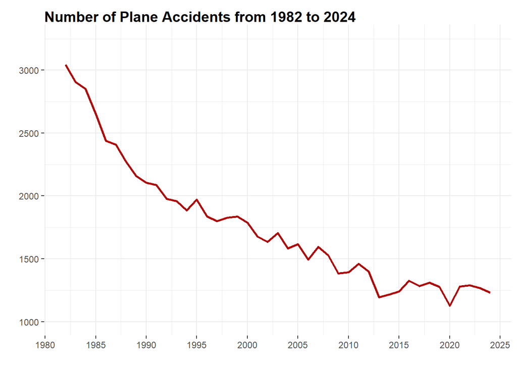

```r
event_yr_plane <- final_events |>
  group_by(year = year(date)) |>
  summarize(Count = n())|>
  filter(year>1981) |>
  filter(year<2025)

ggplot(event_yr_plane, aes(x=year, y=Count)) + geom_line(size=.9, color = "#AC0808") +
  labs(title="Number of Plane Accidents from 1982 to 2024", x="", y="") +
  theme_bw() +
  theme(panel.border = element_blank(),
        plot.title = element_text(hjust = 0, face = "bold", size=14, vjust=-1.0)) +
  scale_x_continuous(breaks = seq(1980, 2025, by = 5)) +
  scale_y_continuous(breaks = seq(1000, 3250, by = 500), limits = c(1000, 3250))
```

Below lies my last attempt trying to using the injure table for some of my visualizations. Most of the wrongly placed cases in the pre2008 table were duplicates (all but one). Thus I only had the post 2008 data to work with in which the data started in 2019. The graphs looked pretty wimpy and were not very useful. Plus the numbers did not seem to be adding up compared to my previous event timeline, so I knew I had to scrap it. Please take a moment of silence for all of my hardwork that led to absolutely nothing…

Injure Timeline:

```r
# if_fatal <- final_injuries |>
#   filter(fatal>0) |>
#   mutate(year = year(date)) |>
#   filter(year<2025) |>
#   group_by(year) |>
#   summarize(count = n())
#
# ggplot(if_fatal, aes(x=year, y=count)) + geom_col(fill = "#AC0808") + labs(x = "", y = "", title = "Number of Plane Accident with Deaths")
#
# sum(duplicated(final_injuries$event))
```

```r
# fatal_yr <- final_injuries |>
#   filter(fatal>0) |>
#   mutate(year = year(date)) |>
#   filter(year<2025) |>
#   group_by(year) |>
#   summarize(count = sum(fatal))
#
# ggplot(fatal_yr, aes(x=year, y=count)) + geom_line(size = 1, color = "#AC0808")
```

Yes, I do know that what lies down below seems crazy. But I was desperate. The next two visualizations used my reasons dataset. The main column I needed was a long description column. The description column kind of branched from a selection of a few possibilities, to another few possibilites, etc. until there was too many exact “findings” categories to count or plot. After a lot thinking, I decided that first plotting the overall source/subject of the findings (aka the first phrase in the description) could give a useful overview. I wanted to include more details (since the description category was very interesting if you took the time to read some cases. There were a few cases of student pilots stealing planes/tools, health problems related to both over the counter and illegal substances, and unfortunately a number of suicides). I thought the most realistic way to get more details yet keep this a possible feat was to use one of the next categories and combine a few very similar cases together (like task management and task performance). Thus I created a unique function just for this dataset that used the power of substring cutting.

Crazy Functions:

```r
#Only to use on this dataset
reason_group <- function(description) {
  if (substr(description, 1, 3)=="Air") {
    return(substr(description, 10,30))
  } else if (substr(description, 1, 3)=="Per") {
    return(substr(description, 18,38))
  } else if (substr(description, 1, 3)=="Env") {
    return(substr(description, 22,42))
  } else if (substr(description, 1, 3)=="Not") {
    return(substr(description, 1,14))
  } else if (substr(description, 1, 3)=="Org") {
    return(substr(description, 23,43))
  } else if (substr(description, 1, 3)=="mai") {
    return("System")
  } else {
    return(NA)
  }
}
```

```r
#Crazy, I know, but it works
reason_subgroup <- function(description) {
   if (substr(description, 1, 15)=="Action/decision") {
    return("Action/decision")
  } else if (substr(description, 1, 19)=="Aircraft structures") {
    return("Aircraft structures")
  } else if ((substr(description, 1, 16)=="Aircraft systems") ||
             (substr(description, 1, 18)=="Aircraft propeller") ||
             (substr(description, 1, 3)=="Flu") ||
             (substr(description, 1, 14)=="Aircraft power") ||
             (substr(description, 1, 3)=="Sys")) {
    return("Aircraft systems")
  } else if (substr(description, 1, 17)=="Aircraft handling") {
    return("Aircraft handling")
  } else if (substr(description, 1, 13)=="Aircraft oper") {
    return("Aircraft performance")
  } else if ((substr(description, 1, 5)=="Condi") ||
             (substr(description, 1, 4)=="Oper")) {
    return("Conditions")
  } else if (substr(description, 1, 5)=="Devel") {
    return("Design/Developmental")
  }  else if ((substr(description, 1, 3)=="Man") ||
              (substr(description, 1, 4)=="Supp")) {
    return("Management")
  } else if (substr(description, 1, 3)=="Exp") {
    return("Experience level")
  } else if ((substr(description, 1, 3)=="Mis") ||
             (substr(description, 1, 3) == "Not")) {
    return("Unique/Unknown")
  } else if (substr(description, 1, 3)=="Phy") {
    return("Physical")
  } else if (substr(description, 1, 3)=="Psy") {
    return("Psychological")
  } else if (substr(description, 1, 4)=="Task") {
    return("Task Management")
  } else {
    return(NA)
  }
}
```

Column Chart:

[figure not shown]

```r
#Data
list_type <- reason|>
  mutate(general = substr(description, 1, 8)) |>
  rowwise() |>
  mutate(type = reason_group(description)) |>
  mutate(type = reason_subgroup(type)) |>
  ungroup() |>
  filter(general != "main sys") |>
  group_by(type, general) |>
  summarize(Count = n()) |>
  group_by(type) |>
  mutate(total_count = sum(Count)) |>
  ungroup() |>
  mutate(type = fct_reorder(type, total_count))


#Plot
ggplot(list_type, aes(x=type, y=Count, fill = general)) +
  geom_col() +
  coord_flip() +
  labs(x="", y="", title = "Categories of Accident Causes from 2020 to 2025", fill=NULL) +
  #Theme
  theme_bw() +
  theme(panel.border = element_blank(),
        panel.grid = element_blank(),
        axis.ticks = element_blank(),
        axis.text.x = element_blank(),
        plot.title = element_text(hjust = .5, face = "bold", size=14)) +
  #Scales
  scale_y_continuous(limits = c(0,18000)) +
  scale_fill_manual(values = c("Organiza" = "#1B0505", "Not dete" = "#DFD2BF","Environm" = "#003c5e", "Aircraft" = "#FAB521", "Personne" = "#AC0808"),
        labels=c("Organization", "Not Determined", "Environment", "Aircraft", "Personnel")) +
  guides(fill = guide_legend(reverse=TRUE)) +
  geom_text(aes(label = total_count, y = total_count), vjust = .5, hjust = -.25, size = 3)
```

The pie chart below shows the proportions of the overall subject that made a mistake or caused an issue leading to the accident. I chose a pie chart because pie charts are good at exhibiting portions in clear ways to the viewer (Desbarats, 2023). There also were not many categories, so a few differently colored slices would represent the different categories well. I did decide to exclude the “main system” category. That category only had something like 3-10 instances and did not show up visibly on either visualization. It was such a tiny proportion, it did not help clarify the graph and only made it more confusing to list. Thus, I removed it. I kept with the color theme (Cesal, 2024). I also included the percentages on the pie chart to give a better reference of the true proportion of the categories(Desbarats, 2023). The last two categories’ labels got caught among different pie slices so I wrote their percentage instead in the legend. I also rounded the percentage to a whole percentage to kep it cleaner and because one tenth of a percentage does not give anyone a better idea of the graph (Few, 2012). I also made sure to match the clockwise color occurence on the pie chart to the legend’s order (top to bottom) for clarity’s sake.

Pie chart:

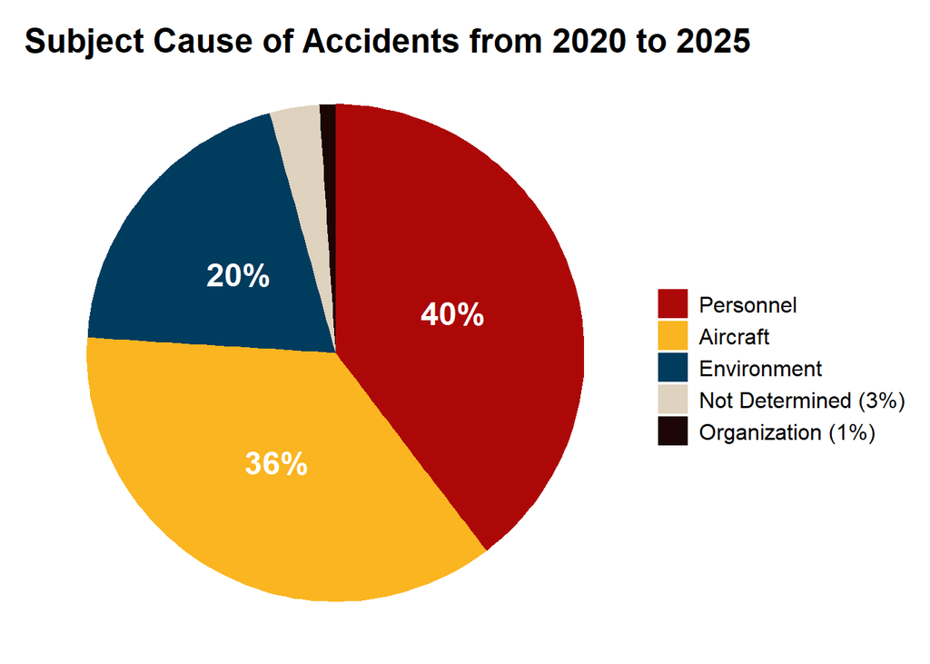

```r
#Data
list_general <- reason|>
  mutate(general = substr(description, 1, 8)) |>
  filter(general != "main sys") |>
  group_by(general) |>
  summarize(Count = n()) |>
  mutate(general = fct_reorder(general, Count),
         per = percent(Count/sum(Count), accuracy = 1),
         label_color = ifelse(general == "Not dete", "black", "white"),
         label = ifelse(Count<2173, NA, per))

#Plot
ggplot(list_general, aes(x="", y=Count, fill=general)) +
  geom_col() +
  coord_polar(theta="y") +
  #Color/Labels
  labs(fill = "", y="", x="", title = "Subject Cause of Accidents from 2020 to 2025") +
  scale_fill_manual(
    values = c("#1B0505", "#DFD2BF", "#003c5e","#FAB521", "#AC0808"), labels=c("Organization (1%)", "Not Determined (3%)", "Environment", "Aircraft", "Personnel")) +
  #Theme/Guides
  theme_void() +
  guides(fill = guide_legend(reverse=TRUE)) +
    theme(plot.title = element_text(hjust = 0, face = "bold", size=18, vjust=-1.5),
          legend.text = element_text(size = 12)) +
  geom_text(aes(label = label), position = position_stack(vjust = 0.5), color = list_general$label_color, size = 6, fontface = "bold")
```

Ah, another wreckage left after another failing I worked on a lot. I was excited to created an interactive world map in which each accident location would be a point on the graph. I was going to set this up in Tableau. However, another problem occurred from the data on the tables. The latitiudes and longitudes were all stored in a different way! They were all stored in the decimal, minute, second format so I thought it would be okay. However, my map was a mess because trailing and leading zeros COULD (as in not always) be meant in a different place than they were. Sometimes they were placeholders. It was so confusing. I thought I could sort it out with a custom function (the exhibit below). However, I ran into cases in which something like “0095431N” and “0095431N” were supposed to be read at times as 95.## degrees and 9.## degrees ( I learned this by researching the realistic latitudes and longitudes based on the city and country given). Thus it was actually impossible to make a decent map unless I went through thousands of cases and based the latitude and longitudes off of the city/country given. What a sad day that was.

DMS lat/long to Decimal Function:

```r
# dms_to_dec <- function(x){
#
#    if (is.na(x) || !is.character(x)){
#      return(NA_real_)
#    }
#
#   if(nchar(x) == 8){ #Longitude has extra char
#     dir <- substr(x, 8, 8)
#     #normal
#     p1 <- as.numeric(substr(x, 1, 3))
#     p2 <- as.numeric(substr(x, 4, 5))
#     p3 <- as.numeric(substr(x, 6, 7))
#     #Error1 : 0 in front needed
#     if(p1>180){
#       p1 <- as.numeric(substr(x, 1, 2))
#       p2 <- as.numeric(substr(x, 3, 4))
#       p3 <- as.numeric(substr(x, 5, 6))
#     }
#     #Error2: 0 in front multiplied
#     if (substr(x, 1, 1) == "0"){
#       if (substr(x, 2, 2) == "0"){
#         #No change
#       } else{
#         t <- as.numeric(substr(x, 2, 3)) * 10
#         if(t <= 180){
#           p1 <- t
#       }
#       }
#
#     }
#
#   }else if (nchar(x)== 7) { #Latitude
#     dir <- substr(x, 7, 7)
#
#     #b/c of some leading zero policy, need to shift
#     if (substr(x, 1, 1)=="0"){
#       if(substr(x,2,2) == 0){
#         p1 <- as.numeric(substr(x, 3, 4))
#         p2 <- as.numeric(substr(x, 5, 5))
#         p3 <- as.numeric(substr(x, 6, 6))
#       }else{
#         p1 <- as.numeric(substr(x, 2, 3))
#         p2 <- as.numeric(substr(x, 4, 5))
#         p3 <- as.numeric(substr(x, 6, 6))
#       }
#     }else{
#       p1 <- as.numeric(substr(x, 1, 2))
#       p2 <- as.numeric(substr(x, 3, 4))
#       p3 <- as.numeric(substr(x, 5, 6))
#     }
#
#   }else {
#     warning(paste("Invalid DMS format:", x))
#     return(NA_real_)
#   }
#
#   ans <- p1+(p2/60)+(p3/3600)
#
#   if (dir %in% c("S", "W")){
#     ans <- -ans
#   }
#
#   return(ans)
# }
```

```r
# map_data <- final_events |>
#   mutate(longitude = ifelse(ev_city == "Angostura",
#          "1081052W", longitude),
#          longitude = ifelse(ev_city == "Rancador, PR",
#          "5217220W", longitude)) |>
#   mutate(lat = sapply(latitude, dms_to_dec),
#          long = sapply(longitude, dms_to_dec))
#
# map_data24 <- map_data |>
#   filter(year(date)>2019) |>
#   filter(year(date)<2025)

# write_json(map_data24, "avMap24.json", pretty = TRUE)
```

US Map:

```r
#Data
valid_states <- c(state.abb, "DC")

map_data <- final_events |>
  rename("state" = ev_state) |>
  filter(state %in% valid_states) |>
  mutate(state = trimws(state)) |>
  group_by(state) |>
  summarize(count = n())

#Plot
s <- plot_usmap(data = map_data, values = "count", regions = "states") + scale_fill_continuous(low = "#DFD2BF", high = "#AC0808", name = "") +
  theme(legend.position = "right") +
  labs(title = "Accidents by State Where Accident Occurred",
       subtitle = "1982-Present") +
  theme(plot.title = element_text(hjust = 1.05, face = "bold", size=14, vjust=-0.6),
        plot.subtitle = element_text(hjust = 0.55),
        legend.background = element_blank())

ggsave("avMap.png", width = 6, height = 5, plot = s, dpi = 500)
```

I was reminded of the small multiples examples we learned about in class, especially some of the calendar examples (Groeger, 2014). Thus, I settled on creating a faceted time graph of last year (2024) and the count of accident on the day they occurred. I thought that a facet of each week of the year would look overwhelming and be a lot of work so I settled on months with 12 facets. For some reason, it seemed easier to read each panel when the x axis was located directly on each panel, rather than the default bottom x axis. For the spacing of the breaks of the x axis, I first tried using a jump of 5 days, but that was much to overwhelming to look at. A jump of 10 days seemed like the perfect middle ground with not too much ink (Tufte, 2001). I also had to change the number of the month to the actual month name so it was readable to the viewer.

Faceted Month Line Plot:

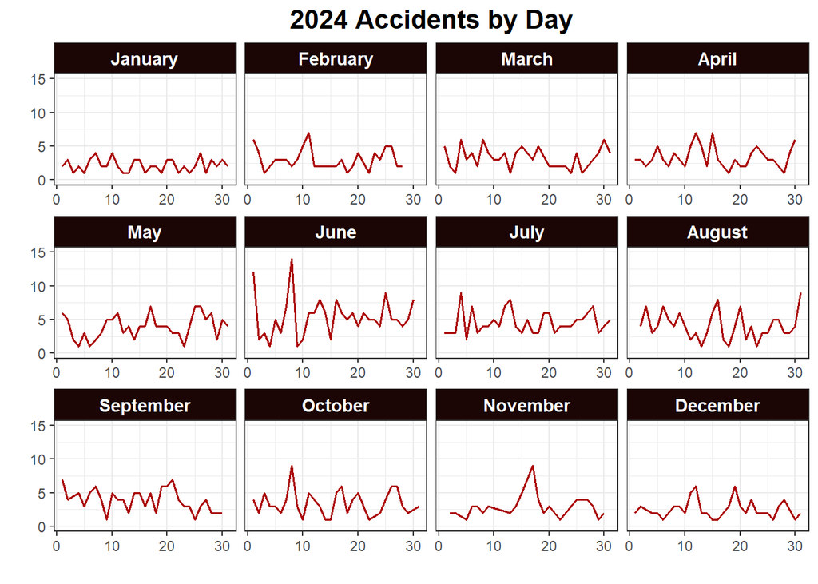

```r
#Data
month_ev24 <- final_events|>
  filter(year(date) == 2024) |>
  mutate(day = day(date),
         month = month(date),
         month = factor(month.name[month], levels = month.name)) |>
  group_by(month, day) |>
  summarize(count = n()) |>
  mutate(col_ex = ifelse(count >= 10, "high", "normal"))

#Plot
ggplot(month_ev24, aes(x=day, y=count)) +
  geom_line(color = "#AC0808", size = 0.7) +
  facet_wrap(~month, scales = "fixed", axes = "all_x") +
  labs(title = "2024 Accidents by Day", x = "", y = "") +
  #Theme
  theme_bw() +
  theme(
    plot.title = element_text(hjust = 0.5, face = "bold", size = 16),
    legend.position = "none",
    strip.background = element_rect(fill = "#1B0505"),
    strip.text = element_text(color = "white", face = "bold", size = 11)
  ) +
  #Scale/Axes
  scale_x_continuous(limits = c(1,31), breaks = seq(0, 31, by = 10)) +
  scale_y_continuous(limits = c(0,15), breaks = seq(0, 15, by = 5)) +
  guides(color = "none")
```

Year Line Plot:

```r
#Data
day_yr <- final_events|>
  mutate(year = "2000", #Dummy yr seemed easiest way to sort/factor
         yr_date = as.Date(
    paste(year, month(date), day(date), sep = "-"))) |>

  group_by(yr_date) |>
  summarize(count = n()) |>

  mutate(max_min = ifelse(count == max(count), as.character(format(yr_date, "%m-%d")),
                          ifelse(count==min(count), as.character(format(yr_date, "%m-%d")),
                                 ifelse(count==91, as.character(format(yr_date, "%m-%d")), NA))))


#Plot
b <- ggplot(day_yr, aes(x=yr_date, y=count)) +
  geom_line(color = "#AC0808") +

  scale_x_date(limits = c(as.Date("2000-01-01"), as.Date("2000-12-31")), date_labels = "%b", date_breaks = "1 month") +
  scale_y_continuous(limits = c(0,400)) +

  labs(x = "", y = "", title = "Accidents by Month and Day", subtitle = "1982 - Present") +
  theme_bw() +
  theme(plot.title = element_text(hjust = 0.5, face = "bold", size = 16),
        plot.subtitle = element_text(hjust = 0.5),
        panel.border = element_blank()) +

  geom_label(aes(label=max_min),
             vjust = ifelse(day_yr$yr_date == as.Date("2000-07-04"), -0.5, 1.3),
             color = "#1B0505", fontface = "bold", size = 3, na.rm = TRUE)

ggsave("avMonthDay.png", width = 6, height = 4, plot = b, dpi = 500)
```

# Annotations of Source Readings

Andrews, R. (2022). How Florence Nightingale Changed Data Visualization Forever. Scientific American. https://www.scientificamerican.com/article/how-florence-nightingale-changed-data-visualization-forever/

Armstrong, Z. (2017). Why Are so Many Babies Born around 8:00 A.M.? Scientific American. https://www.scientificamerican.com/blog/sa-visual/why-are-so-many-babies-born-around-8-00-a-m/

Cesal, A. (2024). How to Create Brand Colors for Data Visualization Style Guidelines | Nightingale. https://nightingaledvs.com/how-to-create-brand-colors-for-data-visualization-style-guidelines/

Desbarats, N. (2023). Have I Resolved the Pie Chart Debate? Nightingale. https://nightingaledvs.com/have-i-resolved-the-pie-chart-debate/

di Bartolomeo, S. (2020). Timelines are not always lines: An evaluation of different timeline shapes. Multiple Views: Visualization Research Explained.

Digital, O. (2016). Does the axis have to start at zero? (Part 1 – line charts). ONS Digital.

Few, S. (2012). Show me the Numbers Chapter 8: Table Design. Show Me the Numbers: Designing Tables and Graphs to Enlighten.

Groeger, L. (2014). A Big Article About Wee Things - Learning - Source: An OpenNews project. Source. https://source.opennews.org/articles/wee-things/

Monmonier, M. (n.d.). How to Lie with Maps Chapter 2: Elements of the map.

Muth, L. C. (2018). What to consider when creating choropleth maps. Datawrapper. https://blog.datawrapper.de/choroplethmaps/

Puhalla, D. (2011). Design Elements Chapter 3: Color Structure. Design Elements, Form and Space: A Graphic Style Manual for Understanding Structure and Design.

Tufte, E. (2001). The Visual Display of Quantitative Information Chapter 6: Data-Ink Maximization and Graphical Design. Graphics Pr.

Yau, N. (2011). Visualize This: Introduction. Visualize This : The Flowingdata Guide to Design, Visualization, and Statistics.